# Pemodelan ARIMA - Data Sunspot Number (Pendugaan Parameter, Diagnostik Model, dan Peramalan)

### Packages

```r
library(ggplot2)
library(tseries)
library(MASS)
library(forecast)
library(TSA)
library(TTR)
library(aTSA)
library(graphics)
library(lmtest)
library(readxl)
```

# Data Sunspot

## Impor Data

Data yang digunakan adalah data *Sunspot Number* (jumlah bintik matahari) harian yang bersumber dari berkas `Data_Sunspot.xlsx`. Data ini terdiri atas 100 observasi harian dengan kolom utama yang digunakan adalah `Sunspot Number`.

```r
data_sunspot <- read_excel("C:\\Users\\najwe\\Downloads\\Data Sunspot.xlsx")
str(data_sunspot)
```

```
## tibble [100 × 8] (S3: tbl_df/tbl/data.frame)
##  $ Year                                : num [1:100] 2026 2026 2026 2026 2026 ...
##  $ Month                               : num [1:100] 4 4 4 4 4 4 4 4 5 5 ...
##  $ Date                                : num [1:100] 23 24 25 26 27 28 29 30 1 2 ...
##  $ Decimal Date                        : num [1:100] 2026 2026 2026 2026 2026 ...
##  $ Sunspot Number                      : num [1:100] 68 94 114 115 117 128 123 135 157 139 ...
##  $ Std Dev                             : num [1:100] 8.7 14.9 13.6 10.8 11.1 14.2 16.9 18.7 15.1 18.1 ...
##  $ Total Obsevations                   : num [1:100] 48 49 39 44 46 39 37 38 37 39 ...
##  $ Status (1 definitive, 0 provisional): num [1:100] 0 0 0 0 0 0 0 0 0 0 ...
```

```r
head(data_sunspot)
```

```
## # A tibble: 6 × 8
##    Year Month  Date `Decimal Date` `Sunspot Number` `Std Dev`
##   <dbl> <dbl> <dbl>          <dbl>            <dbl>     <dbl>
## 1  2026     4    23          2026.               68       8.7
## 2  2026     4    24          2026.               94      14.9
## 3  2026     4    25          2026.              114      13.6
## 4  2026     4    26          2026.              115      10.8
## 5  2026     4    27          2026.              117      11.1
## 6  2026     4    28          2026.              128      14.2
## # ℹ 2 more variables: `Total Obsevations` <dbl>,
## #   `Status (1 definitive, 0 provisional)` <dbl>
```

```r
sunspot <- data_sunspot$`Sunspot Number`
sunspot.ts <- ts(sunspot)
sunspot.ts
```

```
## Time Series:
## Start = 1
## End = 100
## Frequency = 1
##   [1]  68  94 114 115 117 128 123 135 157 139 124 124 132 104  70  75  90  87
##  [19]  79  58  63  50  47  57  84  80  73  66  86 107 118 111 110 146 174 154
##  [37] 138 129 113 100 109 127 127 127 131 133 132 116  96  83  69  48  59  66
##  [55]  70  53  51  61  88  65  70  76  90  87 104 112 130 125 126 132 107 102
##  [73]  89  89  65  58  75  72  71  71  61  39  34  26  47  34  25  45  74  87
##  [91]  81  90  99  95 100 104 100 106 125 118
```

### Pembagian Data

Data kemudian dibagi menjadi data latih dan data uji dengan proporsi 80:20.

```r
n <- length(sunspot.ts)
ntrain <- round(0.8 * n)

train.ts <- ts(sunspot[1:ntrain])
test.ts  <- ts(sunspot[(ntrain + 1):n])

c(Jumlah_Data = n, Data_Latih = length(train.ts), Data_Uji = length(test.ts))
```

```
## Jumlah_Data  Data_Latih    Data_Uji
##         100          80          20
```

## Eksplorasi Data

### Plot Data Penuh

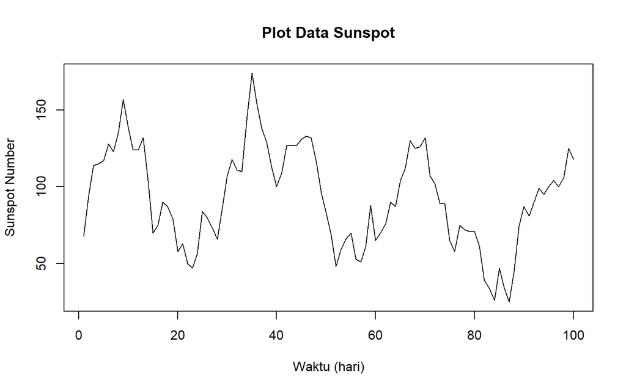

```r
plot.ts(sunspot.ts,
        lty = 1,
        xlab = "Waktu (hari)",
        ylab = "Sunspot Number",
        main = "Plot Data Sunspot")
```

Berdasarkan plot data deret waktu di atas, terlihat bahwa data bergerak naik-turun dengan cukup persisten (nilai yang tinggi cenderung diikuti oleh nilai tinggi berikutnya) tanpa pola musiman yang jelas.

### Plot Data Latih

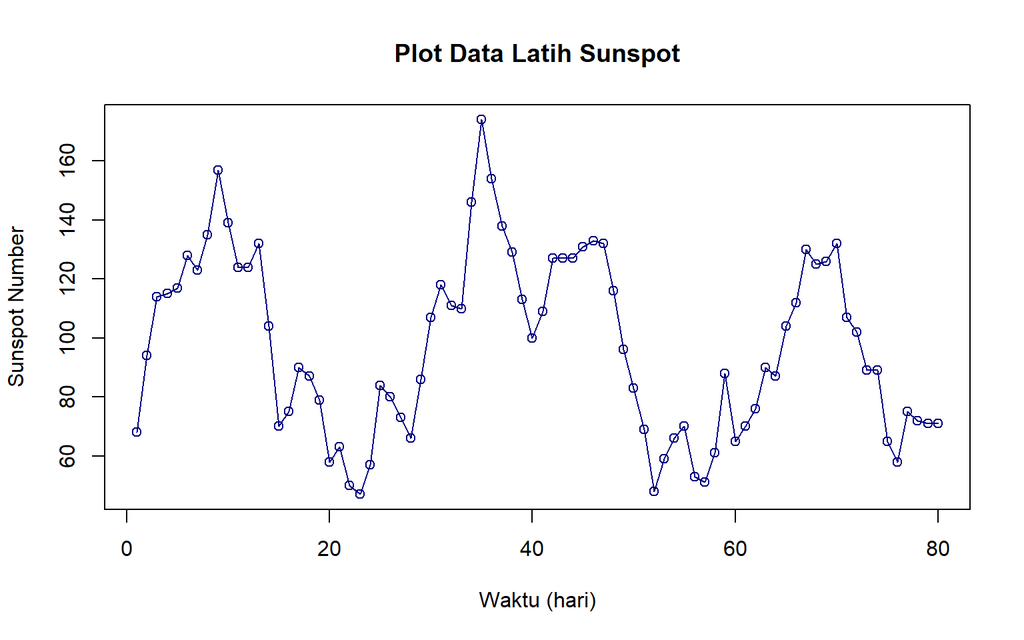

```r
plot.ts(train.ts,
        col = "navyblue",
        lwd = 1,
        type = "o",
        xlab = "Waktu (hari)",
        ylab = "Sunspot Number",
        main = "Plot Data Latih Sunspot")
```

### Plot Data Uji

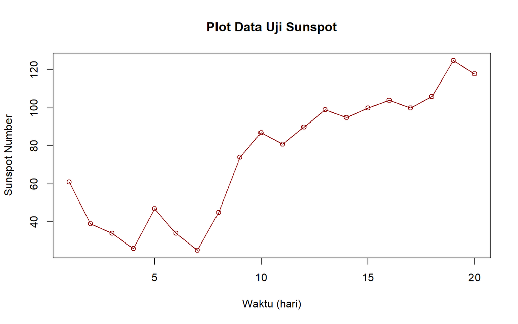

```r
plot.ts(test.ts,
        col = "darkred",
        lwd = 1,
        type = "o",
        xlab = "Waktu (hari)",
        ylab = "Sunspot Number",
        main = "Plot Data Uji Sunspot")
```

## Uji Stasioneritas Data

### Plot ACF

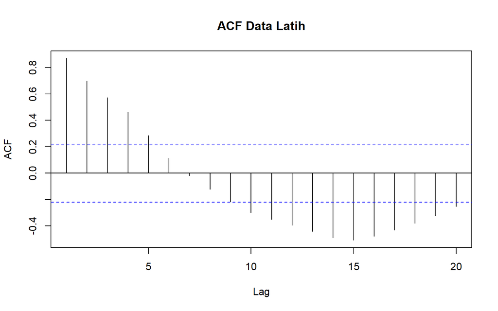

```r
acf(train.ts, main = "ACF Data Latih", lag.max = 20)
```

Berdasarkan plot ACF di atas, terlihat bahwa plot ACF menurun secara perlahan (*tails off slowly*). Hal ini menjadi indikasi awal bahwa data tidak/belum sepenuhnya stasioner dalam rataan.

### Uji ADF

```r
tseries::adf.test(train.ts)
```

```
##
##  Augmented Dickey-Fuller Test
##
## data:  train.ts
## Dickey-Fuller = -3.3878, Lag order = 4, p-value = 0.06349
## alternative hypothesis: stationary
```

$H_0$ : Data tidak stasioner dalam rataan

$H_1$ : Data stasioner dalam rataan

Berdasarkan uji ADF tersebut, didapat *p-value* sebesar 0,0635 yang lebih besar dari taraf nyata 5% sehingga tak tolak $H_0$ dan menandakan bahwa data belum stasioner dalam rataan secara meyakinkan (nilainya berada tepat di sekitar batas taraf nyata). Hal ini sejalan dengan pola *tails off* pada plot ACF sehingga penanganan ketidakstasioneran dalam rataan tetap perlu dilakukan.

### Uji Kestasioneran Ragam (Box-Cox)

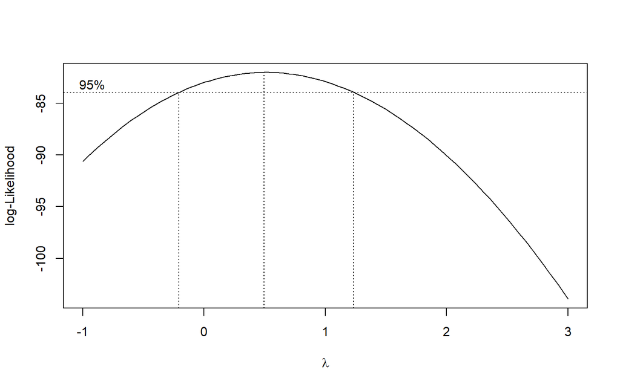

```r
index <- seq(1:ntrain)

bc <- boxcox(train.ts ~ index, lambda = seq(-1, 3, by = 0.1))
```

```r
# Nilai lambda optimum
lambda <- bc$x[which.max(bc$y)]
lambda
```

```
## [1] 0.4949495
```

```r
# Selang kepercayaan 95% untuk lambda
ci_lambda <- bc$x[bc$y > max(bc$y) - 0.5 * qchisq(0.95, 1)]

# Batas bawah dan batas atas
ci_lower <- min(ci_lambda)
ci_upper <- max(ci_lambda)

c(Batas_Bawah = ci_lower, Batas_Atas = ci_upper)
```

```
## Batas_Bawah  Batas_Atas
##  -0.1919192   1.2222222
```

Gambar di atas menunjukkan nilai *rounded value* ($\lambda$) optimum sebesar 0,5 dan pada selang kepercayaan 95% nilai memiliki batas bawah -0,2 dan batas atas 1,2. Selang tersebut memuat nilai satu sehingga dapat dikatakan bahwa data sunspot stasioner dalam ragam sehingga tidak diperlukan transformasi Box-Cox.

## Penanganan Ketidakstasioneran Data

Karena data belum stasioner dalam rataan, dilakukan pembedaan (*differencing*) satu kali.

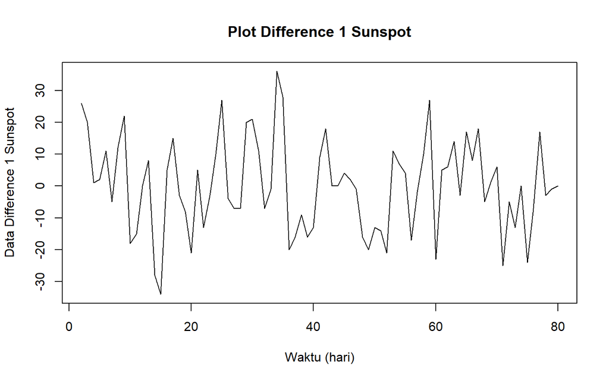

```r
train.diff <- diff(train.ts, differences = 1)

plot.ts(train.diff,
        lty = 1,
        xlab = "Waktu (hari)",
        ylab = "Data Difference 1 Sunspot",
        main = "Plot Difference 1 Sunspot")
```

Berdasarkan plot data deret waktu di atas, terlihat bahwa data sudah bergerak stasioner di sekitar nilai tengahnya (tidak terdapat trend ataupun musiman pada data).

### Plot ACF Data Hasil Differencing

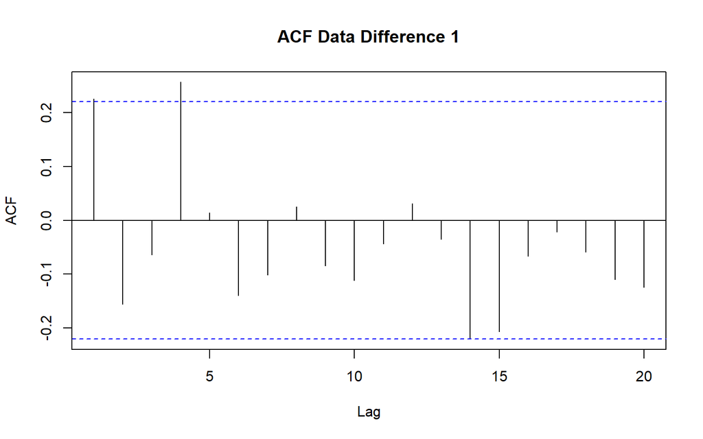

```r
acf(train.diff, main = "ACF Data Difference 1", lag.max = 20)
```

### Uji ADF Data Hasil Differencing

```r
tseries::adf.test(train.diff)
```

```
##
##  Augmented Dickey-Fuller Test
##
## data:  train.diff
## Dickey-Fuller = -3.6767, Lag order = 4, p-value = 0.03228
## alternative hypothesis: stationary
```

$H_0$ : Data tidak stasioner dalam rataan

$H_1$ : Data stasioner dalam rataan

Berdasarkan uji ADF tersebut, didapat *p-value* sebesar 0,0323 yang lebih kecil dari taraf nyata 5% sehingga tolak $H_0$ atau data stasioner dalam rataan. Hal ini sesuai dengan hasil eksplorasi plot time series dan plot ACF, sehingga ketidakstasioneran data telah berhasil tertangani dan dapat dilanjutkan ke tahap identifikasi model.

## Identifikasi Model

### Plot ACF

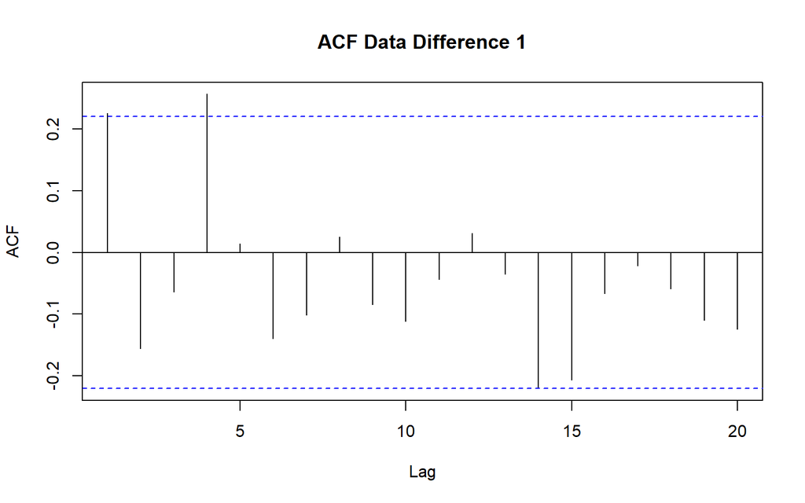

```r
acf(train.diff, main = "ACF Data Difference 1", lag.max = 20)
```

Berdasarkan plot tersebut, plot ACF cenderung *cuts off* pada lag ke-1 (dengan batas signifikansi kurang lebih $\pm 2/\sqrt{n}$), sehingga jika plot PACF dianggap *tails off*, model tentatifnya adalah ARIMA(0,1,1).

### Plot PACF

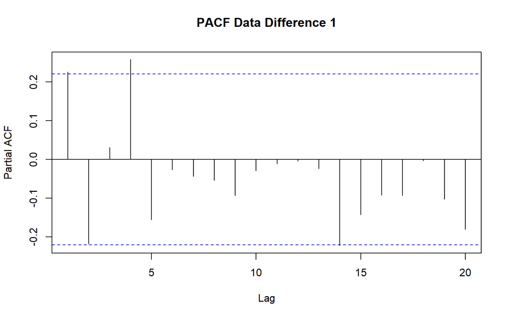

```r
pacf(train.diff, main = "PACF Data Difference 1", lag.max = 20)
```

Berdasarkan plot tersebut, plot PACF juga cenderung *cuts off* pada lag ke-1, sehingga jika plot ACF dianggap *tails off*, model tentatifnya adalah ARIMA(1,1,0).

Jika baik plot ACF maupun plot PACF keduanya dianggap *tails off*, maka model yang terbentuk adalah ARIMA(1,1,1).

### Plot EACF

```r
eacf(train.diff)
```

```
## AR/MA
##   0 1 2 3 4 5 6 7 8 9 10 11 12 13
## 0 o o o x o o o o o o o  o  o  o
## 1 x x o x o o o o o o o  o  o  o
## 2 o x o o o o o o o o o  o  o  o
## 3 o x x o o o o o o o o  o  o  o
## 4 x x o o o o o o o o o  o  o  o
## 5 x o o o o o o o o o o  o  o  o
## 6 x o o o o o o o o o o  o  o  o
## 7 x o o o o o o o o o o  o  o  o
```

Identifikasi model menggunakan plot EACF dilakukan dengan melihat ujung segitiga pada pola segitiga nol. Dalam hal ini model tentatif tambahan yang terbentuk adalah ARIMA(0,1,4) dan ARIMA(2,1,3).

## Pendugaan Parameter Model Tentatif

Berdasarkan identifikasi ACF, PACF, dan EACF di atas, terdapat lima model tentatif yang akan diduga parameternya, yaitu ARIMA(0,1,1), ARIMA(1,1,0), ARIMA(1,1,1), ARIMA(0,1,4), dan ARIMA(2,1,3).

### ARIMA(0,1,1)

```r
model1 <- Arima(train.diff, order = c(0,0,1), method = "ML")
summary(model1) #AIC=648.69
```

```
## Series: train.diff
## ARIMA(0,0,1) with non-zero mean
##
## Coefficients:
##          ma1    mean
##       0.3002  0.1122
## s.e.  0.1040  2.0608
##
## sigma^2 = 204.8:  log likelihood = -321.35
## AIC=648.69   AICc=649.01   BIC=655.8
##
## Training set error measures:
##                      ME     RMSE      MAE MPE MAPE      MASE        ACF1
## Training set -0.0665026 14.12784 11.44019 NaN  Inf 0.8126914 -0.02007472
```

```r
lmtest::coeftest(model1) #ma1 signifikan
```

```
##
## z test of coefficients:
##
##           Estimate Std. Error z value Pr(>|z|)
## ma1        0.30025    0.10398  2.8877 0.003881 **
## intercept  0.11223    2.06080  0.0545 0.956571
## ---
## Signif. codes:  0 '***' 0.001 '**' 0.01 '*' 0.05 '.' 0.1 ' ' 1
```

### ARIMA(1,1,0)

```r
model2 <- Arima(train.diff, order = c(1,0,0), method = "ML")
summary(model2) #AIC=650.50
```

```
## Series: train.diff
## ARIMA(1,0,0) with non-zero mean
##
## Coefficients:
##          ar1    mean
##       0.2319  0.1363
## s.e.  0.1109  2.0868
##
## sigma^2 = 209.6:  log likelihood = -322.25
## AIC=650.5   AICc=650.82   BIC=657.61
##
## Training set error measures:
##                       ME     RMSE      MAE MPE MAPE      MASE       ACF1
## Training set -0.08487408 14.29418 11.54697 NaN  Inf 0.8202769 0.04367306
```

```r
lmtest::coeftest(model2) #ar1 signifikan
```

```
##
## z test of coefficients:
##
##           Estimate Std. Error z value Pr(>|z|)
## ar1        0.23193    0.11091  2.0911  0.03652 *
## intercept  0.13633    2.08676  0.0653  0.94791
## ---
## Signif. codes:  0 '***' 0.001 '**' 0.01 '*' 0.05 '.' 0.1 ' ' 1
```

### ARIMA(1,1,1)

```r
model3 <- Arima(train.diff, order = c(1,0,1), method = "ML")
summary(model3) #AIC=650.61
```

```
## Series: train.diff
## ARIMA(1,0,1) with non-zero mean
##
## Coefficients:
##           ar1     ma1    mean
##       -0.0680  0.3533  0.0996
## s.e.   0.2398  0.2062  2.0086
##
## sigma^2 = 207.3:  log likelihood = -321.31
## AIC=650.61   AICc=651.15   BIC=660.09
##
## Training set error measures:
##                       ME     RMSE      MAE MPE MAPE      MASE        ACF1
## Training set -0.05732926 14.12111 11.42319 NaN  Inf 0.8114833 -0.01004754
```

```r
lmtest::coeftest(model3) #tidak ada parameter (selain intersep) yang signifikan
```

```
##
## z test of coefficients:
##
##            Estimate Std. Error z value Pr(>|z|)
## ar1       -0.068043   0.239806 -0.2837  0.77661
## ma1        0.353341   0.206227  1.7134  0.08665 .
## intercept  0.099595   2.008591  0.0496  0.96045
## ---
## Signif. codes:  0 '***' 0.001 '**' 0.01 '*' 0.05 '.' 0.1 ' ' 1
```

### ARIMA(0,1,4)

```r
model4 <- Arima(train.diff, order = c(0,0,4), method = "ML")
summary(model4) #AIC=647.69
```

```
## Series: train.diff
## ARIMA(0,0,4) with non-zero mean
##
## Coefficients:
##          ma1      ma2      ma3     ma4    mean
##       0.2853  -0.0683  -0.1013  0.2068  0.1373
## s.e.  0.1133   0.1179   0.1387  0.1281  1.9992
##
## sigma^2 = 194.3:  log likelihood = -317.84
## AIC=647.69   AICc=648.85   BIC=661.9
##
## Training set error measures:
##                       ME     RMSE      MAE MPE MAPE      MASE       ACF1
## Training set -0.05061593 13.49166 10.70816 NaN  Inf 0.7606892 0.01848497
```

```r
lmtest::coeftest(model4) #hanya ma1 yang signifikan
```

```
##
## z test of coefficients:
##
##            Estimate Std. Error z value Pr(>|z|)
## ma1        0.285282   0.113309  2.5177  0.01181 *
## ma2       -0.068298   0.117884 -0.5794  0.56234
## ma3       -0.101257   0.138726 -0.7299  0.46545
## ma4        0.206792   0.128062  1.6148  0.10636
## intercept  0.137301   1.999218  0.0687  0.94525
## ---
## Signif. codes:  0 '***' 0.001 '**' 0.01 '*' 0.05 '.' 0.1 ' ' 1
```

### ARIMA(2,1,3)

```r
model5 <- Arima(train.diff, order = c(2,0,3), method = "ML")
summary(model5) #AIC=648.38
```

```
## Series: train.diff
## ARIMA(2,0,3) with non-zero mean
##
## Coefficients:
##           ar1      ar2     ma1     ma2      ma3    mean
##       -0.4224  -0.5494  0.7465  0.5948  -0.0891  0.0310
## s.e.   0.2842   0.2039  0.2909  0.2692   0.1420  1.7189
##
## sigma^2 = 193.2:  log likelihood = -317.19
## AIC=648.38   AICc=649.96   BIC=664.96
##
## Training set error measures:
##                      ME     RMSE      MAE MPE MAPE      MASE         ACF1
## Training set 0.03250266 13.36153 10.44199 NaN  Inf 0.7417807 -0.004860171
```

```r
lmtest::coeftest(model5) #ar2, ma1, ma2 signifikan; ar1 dan ma3 tidak
```

```
##
## z test of coefficients:
##
##            Estimate Std. Error z value Pr(>|z|)
## ar1       -0.422434   0.284204 -1.4864 0.137180
## ar2       -0.549373   0.203943 -2.6938 0.007065 **
## ma1        0.746523   0.290914  2.5661 0.010284 *
## ma2        0.594762   0.269219  2.2092 0.027160 *
## ma3       -0.089105   0.142013 -0.6274 0.530372
## intercept  0.031025   1.718857  0.0181 0.985599
## ---
## Signif. codes:  0 '***' 0.001 '**' 0.01 '*' 0.05 '.' 0.1 ' ' 1
```

## Perbandingan AIC dan BIC

```r
model_tentatif <- data.frame(
  Model = c("ARIMA(0,1,1)", "ARIMA(1,1,0)", "ARIMA(1,1,1)",
            "ARIMA(0,1,4)", "ARIMA(2,1,3)"),
  AIC   = c(AIC(model1), AIC(model2), AIC(model3), AIC(model4), AIC(model5)),
  BIC   = c(BIC(model1), BIC(model2), BIC(model3), BIC(model4), BIC(model5))
)

model_tentatif
```

```
##          Model      AIC      BIC
## 1 ARIMA(0,1,1) 648.6940 655.8023
## 2 ARIMA(1,1,0) 650.5043 657.6126
## 3 ARIMA(1,1,1) 650.6136 660.0914
## 4 ARIMA(0,1,4) 647.6880 661.9047
## 5 ARIMA(2,1,3) 648.3780 664.9642
```

## Overfitting

Tahap selanjutnya adalah *overfitting* yang dilakukan dengan menaikkan orde AR(p) dan MA(q) dari model ARIMA(0,1,1). Kandidat model *overfitting* adalah ARIMA(1,1,1) dan ARIMA(0,1,2).

```r
#ARIMA(1,1,1) sudah diduga sebagai model3 di atas
summary(model3) #AIC=650.61, ar1 tidak signifikan
```

```
## Series: train.diff
## ARIMA(1,0,1) with non-zero mean
##
## Coefficients:
##           ar1     ma1    mean
##       -0.0680  0.3533  0.0996
## s.e.   0.2398  0.2062  2.0086
##
## sigma^2 = 207.3:  log likelihood = -321.31
## AIC=650.61   AICc=651.15   BIC=660.09
##
## Training set error measures:
##                       ME     RMSE      MAE MPE MAPE      MASE        ACF1
## Training set -0.05732926 14.12111 11.42319 NaN  Inf 0.8114833 -0.01004754
```

```r
model1b <- Arima(train.diff, order = c(0,0,2), method = "ML")
summary(model1b) #AIC=650.49
```

```
## Series: train.diff
## ARIMA(0,0,2) with non-zero mean
##
## Coefficients:
##          ma1      ma2    mean
##       0.2625  -0.0505  0.0785
## s.e.  0.1260   0.1090  1.9224
##
## sigma^2 = 207:  log likelihood = -321.24
## AIC=650.49   AICc=651.03   BIC=659.97
##
## Training set error measures:
##                       ME    RMSE      MAE MPE MAPE      MASE        ACF1
## Training set -0.04071088 14.1103 11.38466 NaN  Inf 0.8087465 0.006553646
```

```r
lmtest::coeftest(model1b) #ma2 tidak signifikan
```

```
##
## z test of coefficients:
##
##            Estimate Std. Error z value Pr(>|z|)
## ma1        0.262541   0.126011  2.0835  0.03721 *
## ma2       -0.050469   0.109043 -0.4628  0.64348
## intercept  0.078533   1.922443  0.0409  0.96742
## ---
## Signif. codes:  0 '***' 0.001 '**' 0.01 '*' 0.05 '.' 0.1 ' ' 1
```

```r
overfitting <- data.frame(
  Model = c("ARIMA(0,1,1)", "ARIMA(1,1,1)", "ARIMA(0,1,2)"),
  AIC   = c(AIC(model1), AIC(model3), AIC(model1b)),
  BIC   = c(BIC(model1), BIC(model3), BIC(model1b))
)

overfitting
```

```
##          Model      AIC      BIC
## 1 ARIMA(0,1,1) 648.6940 655.8023
## 2 ARIMA(1,1,1) 650.6136 660.0914
## 3 ARIMA(0,1,2) 650.4879 659.9657
```

Kedua model hasil *overfitting* memiliki AIC yang lebih besar dibandingkan model ARIMA(0,1,1) dan terdapat parameter tambahan yang tidak signifikan. Oleh karena itu, model ARIMA(0,1,1) tetap digunakan sebagai model terbaik untuk melakukan peramalan.

## Model Terbaik: ARIMA(0,1,1)

```r
model.terbaik <- Arima(train.diff, order = c(0,0,1), method = "ML")
summary(model.terbaik)
```

```
## Series: train.diff
## ARIMA(0,0,1) with non-zero mean
##
## Coefficients:
##          ma1    mean
##       0.3002  0.1122
## s.e.  0.1040  2.0608
##
## sigma^2 = 204.8:  log likelihood = -321.35
## AIC=648.69   AICc=649.01   BIC=655.8
##
## Training set error measures:
##                      ME     RMSE      MAE MPE MAPE      MASE        ACF1
## Training set -0.0665026 14.12784 11.44019 NaN  Inf 0.8126914 -0.02007472
```

```r
lmtest::coeftest(model.terbaik)
```

```
##
## z test of coefficients:
##
##           Estimate Std. Error z value Pr(>|z|)
## ma1        0.30025    0.10398  2.8877 0.003881 **
## intercept  0.11223    2.06080  0.0545 0.956571
## ---
## Signif. codes:  0 '***' 0.001 '**' 0.01 '*' 0.05 '.' 0.1 ' ' 1
```

## Analisis Sisaan

Model terbaik hasil identifikasi kemudian dicek asumsi sisaannya. Sisaan model ARIMA harus memenuhi asumsi normalitas, kebebasan, dan kehomogenan ragam. Diagnostik model dilakukan secara eksplorasi dan uji formal.

### Eksplorasi Sisaan

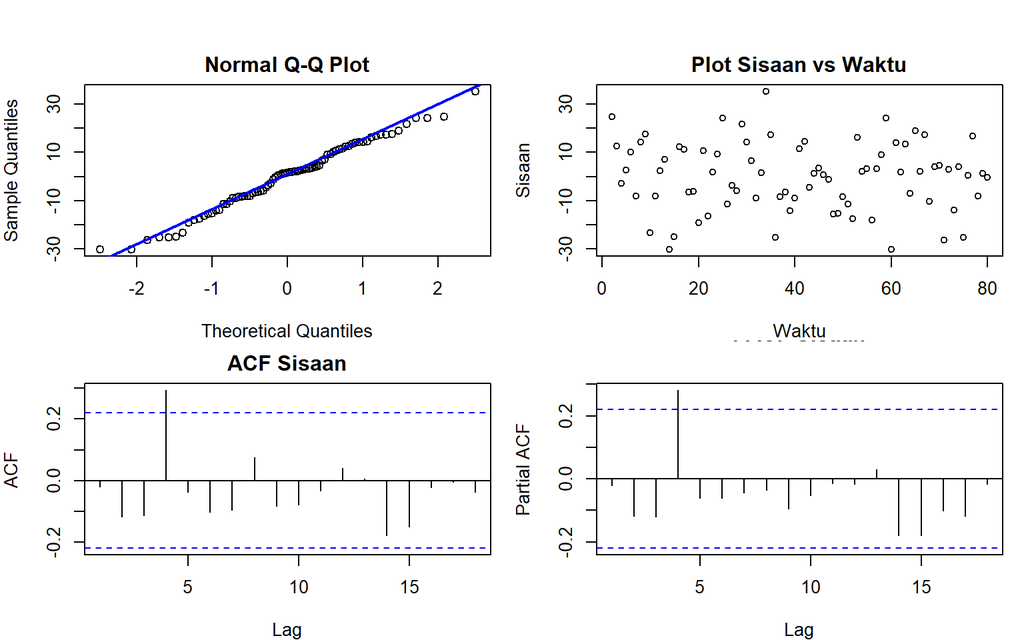

```r
sisaan <- model.terbaik$residuals

par(mfrow = c(2,2),
    mar = c(4,4,2,1),
    oma = c(0,0,2,0))

# Q-Q Plot
qqnorm(sisaan, main = "Normal Q-Q Plot")
qqline(sisaan, col = "blue", lwd = 2)

# Plot Sisaan vs Waktu
plot(sisaan, type = "p",
     main = "Plot Sisaan vs Waktu",
     xlab = "Waktu", ylab = "Sisaan")

# ACF Sisaan
acf(sisaan, main = "ACF Sisaan")

# PACF Sisaan
pacf(sisaan, main = "PACF Sisaan")
```

```r
par(mfrow = c(1,1))
```

### Uji Formal

```r
#1) Sisaan menyebar normal
ks.test(sisaan, "pnorm", mean(sisaan), sd(sisaan))
```

```
##
##  Exact one-sample Kolmogorov-Smirnov test
##
## data:  sisaan
## D = 0.072724, p-value = 0.77
## alternative hypothesis: two-sided
```

```r
#gagal tolak H0 > sisaan menyebar normal
```

$H_0$ : Sisaan menyebar normal

$H_1$ : Sisaan tidak menyebar normal

Berdasarkan uji KS tersebut, didapat *p-value* sebesar 0,77 yang lebih besar dari taraf nyata 5% sehingga gagal tolak $H_0$ dan menandakan bahwa sisaan menyebar normal. Hal ini sesuai dengan hasil eksplorasi menggunakan plot kuantil-kuantil normal.

```r
#2) Sisaan saling bebas/tidak ada autokorelasi
Box.test(sisaan, type = "Ljung-Box")
```

```
##
##  Box-Ljung test
##
## data:  sisaan
## X-squared = 0.033061, df = 1, p-value = 0.8557
```

```r
#gagal tolak H0 > sisaan saling bebas
```

$H_0$ : Sisaan saling bebas

$H_1$ : Sisaan tidak saling bebas

Berdasarkan uji Ljung-Box tersebut, didapat *p-value* sebesar 0,856 yang lebih besar dari taraf nyata 5% sehingga gagal tolak $H_0$ dan menandakan bahwa sisaan saling bebas.

```r
#3) Sisaan homogen
Box.test((sisaan)^2, type = "Ljung-Box")
```

```
##
##  Box-Ljung test
##
## data:  (sisaan)^2
## X-squared = 0.13694, df = 1, p-value = 0.7113
```

```r
#gagal tolak H0 > sisaan homogen
```

$H_0$ : Ragam sisaan homogen

$H_1$ : Ragam sisaan tidak homogen

Berdasarkan uji Ljung-Box terhadap sisaan kuadrat tersebut, didapat *p-value* sebesar 0,711 yang lebih besar dari taraf nyata 5% sehingga gagal tolak $H_0$ dan menandakan bahwa ragam sisaan homogen.

```r
#4) Nilai tengah sisaan sama dengan nol
t.test(sisaan, mu = 0, conf.level = 0.95)
```

```
##
##  One Sample t-test
##
## data:  sisaan
## t = -0.041573, df = 78, p-value = 0.9669
## alternative hypothesis: true mean is not equal to 0
## 95 percent confidence interval:
##  -3.251151  3.118145
## sample estimates:
##  mean of x
## -0.0665026
```

```r
#gagal tolak H0 > nilai tengah sisaan sama dengan 0
```

$H_0$ : Nilai tengah sisaan sama dengan 0

$H_1$ : Nilai tengah sisaan tidak sama dengan 0

Berdasarkan uji-t tersebut, didapat *p-value* sebesar 0,967 yang lebih besar dari taraf nyata 5% sehingga gagal tolak $H_0$ dan menandakan bahwa nilai tengah sisaan sama dengan nol.

Secara keseluruhan, model ARIMA(0,1,1) telah memenuhi seluruh asumsi sisaan (normalitas, kebebasan, kehomogenan ragam, dan nilai tengah nol) sehingga model ini layak digunakan untuk peramalan.

## Peramalan

Peramalan dilakukan menggunakan fungsi `forecast()` untuk sejumlah periode data uji yang tersedia (20 hari ke depan).

```r
#---FORECAST---#
ramalan <- forecast::forecast(model.terbaik, h = length(test.ts))
ramalan
```

```
##     Point Forecast     Lo 80   Hi 80     Lo 95    Hi 95
##  81    -0.04147897 -18.38066 18.2977 -28.08883 28.00588
##  82     0.11222590 -19.03575 19.2602 -29.17208 29.39653
##  83     0.11222590 -19.03575 19.2602 -29.17208 29.39653
##  84     0.11222590 -19.03575 19.2602 -29.17208 29.39653
##  85     0.11222590 -19.03575 19.2602 -29.17208 29.39653
##  86     0.11222590 -19.03575 19.2602 -29.17208 29.39653
##  87     0.11222590 -19.03575 19.2602 -29.17208 29.39653
##  88     0.11222590 -19.03575 19.2602 -29.17208 29.39653
##  89     0.11222590 -19.03575 19.2602 -29.17208 29.39653
##  90     0.11222590 -19.03575 19.2602 -29.17208 29.39653
##  91     0.11222590 -19.03575 19.2602 -29.17208 29.39653
##  92     0.11222590 -19.03575 19.2602 -29.17208 29.39653
##  93     0.11222590 -19.03575 19.2602 -29.17208 29.39653
##  94     0.11222590 -19.03575 19.2602 -29.17208 29.39653
##  95     0.11222590 -19.03575 19.2602 -29.17208 29.39653
##  96     0.11222590 -19.03575 19.2602 -29.17208 29.39653
##  97     0.11222590 -19.03575 19.2602 -29.17208 29.39653
##  98     0.11222590 -19.03575 19.2602 -29.17208 29.39653
##  99     0.11222590 -19.03575 19.2602 -29.17208 29.39653
## 100     0.11222590 -19.03575 19.2602 -29.17208 29.39653
```

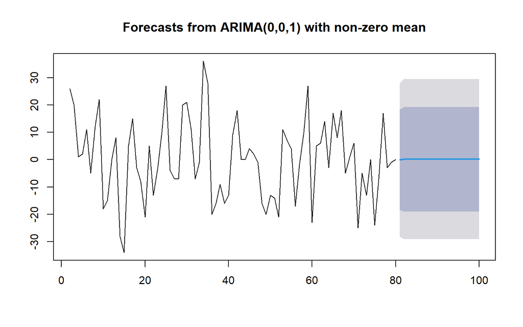

```r
plot(ramalan)
```

```r
data.ramalan <- ramalan$mean

# Inverse differencing (mengembalikan hasil ramalan ke skala data asli)
pt_akhir_train <- tail(train.ts, 1)

hasil.diffinv <- diffinv(data.ramalan, differences = 1, xi = pt_akhir_train)
hasil <- hasil.diffinv[-1]

# Bandingkan aktual vs forecast
perbandingan <- data.frame(
  Aktual   = as.numeric(test.ts),
  Forecast = round(hasil, 2)
)

perbandingan
```

```
##    Aktual Forecast
## 1      61    70.96
## 2      39    71.07
## 3      34    71.18
## 4      26    71.30
## 5      47    71.41
## 6      34    71.52
## 7      25    71.63
## 8      45    71.74
## 9      74    71.86
## 10     87    71.97
## 11     81    72.08
## 12     90    72.19
## 13     99    72.31
## 14     95    72.42
## 15    100    72.53
## 16    104    72.64
## 17    100    72.75
## 18    106    72.87
## 19    125    72.98
## 20    118    73.09
```

```r
# Hitung akurasi
akurasi_test <- forecast::accuracy(hasil, as.numeric(test.ts))
akurasi_test
```

```
##                ME     RMSE      MAE       MPE     MAPE
## Test set 2.475333 31.30983 28.45638 -24.64323 54.39412
```

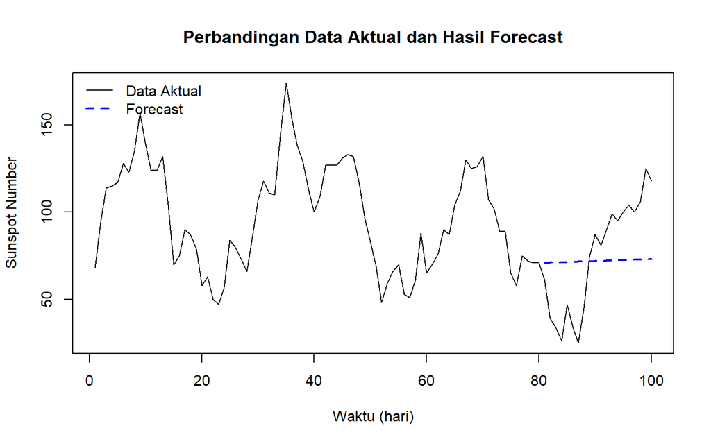

```r
# Plot perbandingan data aktual dan hasil forecast
ts.plot(sunspot.ts, col = "black", lty = 1,
        xlab = "Waktu (hari)", ylab = "Sunspot Number",
        main = "Perbandingan Data Aktual dan Hasil Forecast")

lines((ntrain + 1):n, hasil, col = "blue", lty = 2, lwd = 2)
legend("topleft",
       legend = c("Data Aktual", "Forecast"),
       col = c("black", "blue"),
       lty = c(1,2), lwd = c(1,2), bty = "n")
```

## Kesimpulan

Berdasarkan seluruh tahapan pemodelan ARIMA terhadap data *Sunspot Number*, dapat disimpulkan sebagai berikut.

1. Data sunspot pada level awal belum sepenuhnya stasioner dalam rataan (mengikuti pola ACF yang *tails off slowly* dan *p-value* uji ADF di sekitar taraf nyata 5%), tetapi sudah stasioner dalam ragam (selang kepercayaan Box-Cox memuat nilai satu).
2. Setelah dilakukan *differencing* satu kali, data menjadi stasioner dalam rataan (uji ADF *p-value* = 0,0323).
3. Berdasarkan identifikasi ACF, PACF, EACF, serta pendugaan dan pemilihan model terbaik berdasarkan AIC/BIC dan signifikansi parameter, model terbaik yang diperoleh adalah **ARIMA(0,1,1)**.
4. Model ARIMA(0,1,1) telah memenuhi seluruh asumsi sisaan (normalitas, kebebasan, kehomogenan ragam, dan nilai tengah sisaan sama dengan nol).
5. Hasil peramalan terhadap 20 data uji menunjukkan model cenderung mendekati nilai rataan/level akhir data latih pada periode-periode awal ramalan, dengan tingkat akurasi (MAPE) di atas 50%, yang menandakan bahwa pergerakan naik-turun tajam pada data sunspot harian cukup sulit ditangkap oleh model ARIMA sederhana ini dan dapat menjadi catatan untuk eksplorasi model musiman/nonlinear pada kajian lanjutan.